# The old normal

NDH802 - Spring 2022

### Exercise 5.27

First, type in the assumptions from the question.

```r
mu = 500000
sigma = 50000
```

**(a) What is the probability that the cost of building a home will be between $460,000 and $540,000? That is, find** $P(460,000 < X < 540,000)$ **where** $X$ **denotes the cost?**  
What we want to compute is the *blue* area. To do that in base R, one way is to compute the gray area, then subtract the pink area from it.

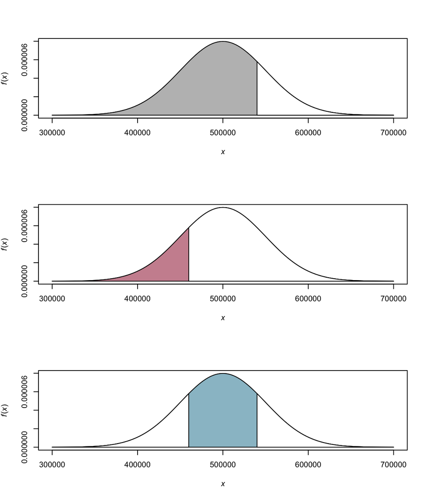

To compute the area below the normal curve, we use `pnorm()`.

```r
grey = pnorm(540000, mean = mu, sd = sigma)
pink = pnorm(460000, mean = mu, sd = sigma)
blue = grey - pink; cat(blue)
```

```
## 0.5762892
```

*Can you suggest another way to compute the blue area?*  
Hint: The total area below the normal curve is 1 and `pnorm()` can compute the area from either tails. Try `?pnorm` and check out the argument `lower.tail`.

```r
# blue_alternative <- 1 - #total area below the curve
#   pnorm(460000, mean = mu, sd = sigma) - #the white area on the left
#   pnorm(540000, mean = mu, sd = sigma, lower.tail = FALSE) #the white area on the right
# cat(blue_alternative)
```

**(b) What probability is 0.2 that the cost of building will be less than what amount? That is, find** $a$ **such that** $P(X < a) = 0.2$**?**

```r
a = qnorm(0.2, mean = mu, sd = sigma)
cat(a)
```

```
## 457918.9
```

**(c) Find the shortest range such that the probability is 0.95 that the cost of a luxury home will fall in this range. That is, find** $b$ **and** $c$ **such that** $P(b < X < c) = 0.95$**?**  
The graph is, again, for illustration purpose, you don’t need to learn to code it. Notice the lavender area is 0.95.

```r
b = qnorm(0.025, mean = mu, sd = sigma)
c = qnorm(0.975, mean = mu, sd = sigma)
```

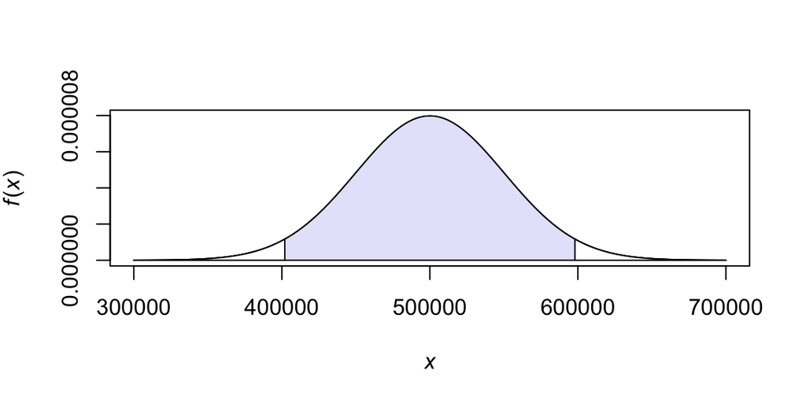

*NOTE*  
- In (a), we compute the **area** under the curve (the gray/pink/blue area) which characterizes the **probability**.  
- In (b) and (c), we compute the **value** of $X$ (a point on the x-axis) which characterizes **the cost of building a home**.